# Bootstrap testing of procrustes hypothesis

Charles Zheng

12/16/2015

Let $X$ and $Y$ be indepedent $p \times q$ random matrices, with distributions $F$ and $G$ respectively. Let $A = E[X]$ and $B = E[Y]$. The goal is to test the *Procrustes hypothesis*

$H_0: A^T A = B^T B$

or equivalently, that there exists $\Omega$ orthogonal such that $\Omega A = B$. The data consists of i.i.d. indpendent realizations $X^{(1)}, ..., X^{(n_x)}$ and $Y^{(1)},..., Y^{(n_y)}$.

*Example:* We are testing the congruence of two physical objects. The $q$ columns of $A$ consist of the true positions of $q$ labelled landmarks on the first object, measured according to some orthogonal coordinate system. The $q$ columns of $B$ give the positions of the corresponding landmarks of the second object, measured using a different orthogonal system compared to the first. Both sets of positions are centered and standardized using an $(q + 1)$ th landmark which is used to define the origin. $A$ and $B$ are not observed directly; instead, they must be inferred from unbiased, noisy measurements $X$ and $Y$ respectively.

The situation is depicted in Figure 1.

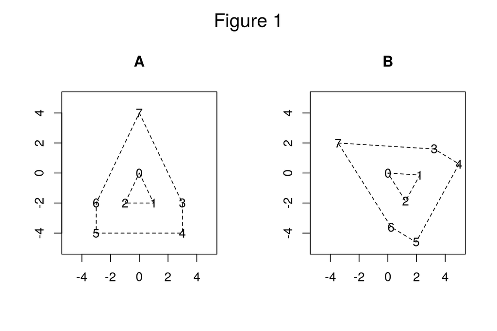

```r
library(pracma)
shape.inner <- matrix(c(0,0, 1,-2, -1,-2, 0,0), 2, 4)
shape.outer <- matrix(c(0,4, 3,-2, 3,-4, -3,-4, -3,-2, 0,4), 2, 6)
A <- cbind(shape.inner[, -4], shape.outer[, -1])
theta <- pi/3; Omega0 <- matrix(c(cos(theta), sin(theta), -sin(theta), cos(theta)), 2, 2)
B <- Omega0 %*% A
par(mfrow=c(1,2),oma = c(0, 0, 2, 0))
plot(NA, NA, xlim = c(-5, 5), ylim = c(-5, 5), ann = FALSE); title("A")
for (i in 1:8) text(t(A[, i]), paste(i-1))
polygon(t(shape.inner), lty = 2); polygon(t(shape.outer), lty = 2)
plot(NA, NA, xlim = c(-5, 5), ylim = c(-5, 5), ann = FALSE); title("B")
polygon(t(Omega0 %*% shape.inner), lty = 2); polygon(t(Omega0 %*% shape.outer), lty = 2)
for (i in 1:8) text(t(B[, i]), paste(i-1))
mtext("Figure 1", outer = TRUE, cex = 1.5)
```

# Procrustes analysis

A natural analysis of this problem is as follows. Obtain $\hat{A} = \bar{X}$, and $\hat{B} = \bar{Y}$. Then look for a rotation matrix $R$ which minimizes

$||R\hat{A} - \hat{B}||_F^2.$

The solution to the above optimization problem was derived by Schonemann (1964). Having obtained the SVD decomposition $\hat{B}\hat{A}^T = V D U^T,$ the optimal rotation is given by $R = VU^T.$

# Data model

The data is given in the form of two samples, $X^{(1)}, ..., X^{(n_x)}$ and $Y^{(1)},..., Y^{(n_y)}$. In order to conveniently apply resampling methods, let us adopt the following one-sample sampling model: the data is given in the form of ordered pairs $(0, X^{(1)}), ..., (0, X^{(n_x)}), (1, Y^{(1)}),..., (1, Y^{(n_y)})$. Then any one-sample resampling method can be applied to the data.

The data model is given in code as follows.

`procrustes_data_model_` is a function which takes as inputs:

- The true parameters $A$, $B$
- A covariance matrix $\Sigma_X$ for the noise in each column of $X$.
- A covariance matrix $\Sigma_Y$

The output is a function `sampler(nX, nY)`, which produces $n_X$ observations of $X$ and $n_Y$ observations of $Y$ (vectorized) plus metadata; `sampler(0,0)` produces noiseless observations.

```r
library(MASS)

f2 <- function(x, y = 0) sum((x-y)^2)

procrustes_data_model_ <- function(A, B, SigmaX, SigmaY) {
  p <- dim(A)[1]; q <- dim(A)[2]
  vecA <- as.numeric(A)
  vecB <- as.numeric(B)
  sampler <- function(nX, nY) {
    noise_mult <- 1
    if (nX == 0 && nY == 0) {
      nX <- 1; nY <- 1
      noise_mult <- 0
    }
    rawX <- repmat(vecA, nX, 1)
    temp <- noise_mult * t(mvrnorm(nX * q, rep(0, p), SigmaX))
    rawX <- t(t(rawX) + as.numeric(temp))
    rawY <- repmat(vecB, nY, 1)
    temp <- noise_mult * t(mvrnorm(nY * q, rep(0, p), SigmaY))
    rawY <- t(t(rawY) + as.numeric(temp))
    dat <- rbind(cbind(0, rawX), cbind(1, rawY))
    list(p = p, q  = q, dat = dat)
  }
  # force eval
  lala <- sampler(10, 10)
  sampler
}

## computes Ahat and Bhat
sample_moments <- function(res) {
  p <- res$p; q <- res$q; dat <- res$dat
  rawX <- dat[dat[,1] == 0, -1, drop = FALSE]
  rawY <- dat[dat[,1] == 1, -1, drop = FALSE]
  Ahat <- matrix(colMeans(rawX), p, q)
  Bhat <- matrix(colMeans(rawY), p, q)
  list(Ahat = Ahat, Bhat = Bhat)
}
```

To test the code, we define null (h0) models and a non-null (h1) model, for a variety of dimensionalities.

```r
p <- 5
q <- 2
SigmaX <- 3 * cov(randn(2*p, p)); SigmaY <- 3 * cov(randn(2 * p, p))

A_0 <- randn(p, q); B_0 <- svd(randn(p, p))$u %*% A_0
h0_small <- procrustes_data_model_(A_0, B_0, SigmaX, SigmaY)

A_1 <- randn(p, q); B_1 <- randn(p, q)
h1_small <- procrustes_data_model_(A_1, B_1, SigmaX, SigmaY)

dat <- h0_small(100, 200)
mus <- sample_moments(dat)
c(f2(mus$Ahat, A_0), f2(mus$Bhat, B_0))
```

```
## [1] 0.26116635 0.08394876
```

```r
dat <- h0_small(0, 0)
mus <- sample_moments(dat)
c(f2(mus$Ahat, A_0), f2(mus$Bhat, B_0))
```

```
## [1] 0 0
```

```r
p <- 20; q <- 10
SigmaX <- cov(randn(2*p, p)); SigmaY <- cov(randn(2 * p, p))
A <- randn(p, q); B <- svd(randn(p, p))$u %*% A
h0_med1 <- procrustes_data_model_(A, B, SigmaX, SigmaY)
B <- randn(p, q)
h1_med1 <- procrustes_data_model_(A, B, SigmaX, SigmaY)

p <- 30; q <- 2
SigmaX <- cov(randn(2*p, p)); SigmaY <- cov(randn(2 * p, p))
A <- randn(p, q); B <- svd(randn(p, p))$u %*% A
h0_med2 <- procrustes_data_model_(A, B, SigmaX, SigmaY)
B <- randn(p, q)
h1_med2 <- procrustes_data_model_(A, B, SigmaX, SigmaY)

p <- 15; q <- 15
SigmaX <- cov(randn(2*p, p)); SigmaY <- cov(randn(2 * p, p))
A <- randn(p, q); B <- svd(randn(p, p))$u %*% A
h0_med3 <- procrustes_data_model_(A, B, SigmaX, SigmaY)
B <- randn(p, q)
h1_med3 <- procrustes_data_model_(A, B, SigmaX, SigmaY)
```

# Test statistics

$T = VU^T \hat{A} - \hat{B}.$

$S = \hat{A}^T \hat{A} - \hat{B}^T\hat{B}.$

The test statistics are given in code as follows

```r
stat.T <- function(res) {
  mus <- sample_moments(res)
  res <- svd(mus$Ahat %*% t(mus$Bhat))
  R <- res$v %*% t(res$u)
  stat.T.raw <- R %*% mus$Ahat - mus$Bhat
  as.numeric(stat.T.raw)
}

stat.S <- function(res) {
  mus <- sample_moments(res)
  stat.S.raw <- t(mus$Ahat) %*% mus$Ahat - t(mus$Bhat) %*% mus$Bhat
  as.numeric(stat.S.raw)
}

nm_ <- function(theta) {
  newf <- function(res) {
    f2(theta(res))
  }
  newf
}

stat.T.nm <- nm_(stat.T)
stat.S.nm <- nm_(stat.S)
```

# Estimating bias and variance with jackknife

True bias and variance, skewness of test statistics.

```r
sampling_dist <- function(sampler, theta, nX, nY, mc.reps = 1e3, samples = FALSE) {
  # true params
  dat0 <- sampler(0, 0)
  theta0 <- theta(dat0)
  # get population
  thetas <- lapply(1:mc.reps, function(i) theta(sampler(nX, nY)))
  thetas <- do.call(cbind, thetas)
  if (samples) {
    return(thetas)
  }
  diffs <- thetas - theta0
  bias <- rowMeans(diffs)
  sdv <- apply(diffs, 1, sd)
  skew <- rowSums(diffs^3)/(rowSums(diffs^2))^(3/2)
  list(bias = bias, sdv = sdv, skew = skew)
}
```

Jackknife estimates of bias and variance.

```r
jackknife <- function(res, theta) {
  theta0 <- theta(res)
  n <- dim(res$dat)[1]
  thetas <- list()
  for (i in 1:n) {
    dat2 <- res$dat[-i, , drop = FALSE]
    thetas[[i]] <- theta(list(p = res$p, q = res$q, dat = dat2))
  }
  thetas <- do.call(cbind, thetas)
  theta_bar <- rowMeans(thetas)
  diffs <- thetas - theta_bar
  bias <- (n-1) * (theta_bar - theta0)
  sdv <- sqrt((n-1) * rowMeans((thetas - theta_bar)^2))
  skew <- rowSums(diffs^3)/(rowSums(diffs^2))^(3/2)
  list(bias = bias, sdv = sdv, skew = skew)
}
```

Compare jackknife estimates to truth

```r
sampler <- h0_small
theta <- stat.S.nm
nX <- 20; nY <- 20
res.true <- sampling_dist(sampler, theta, nX, nY)
res.true
```

```
## $bias
## [1] 18.91483
##
## $sdv
## [1] 20.54697
##
## $skew
## [1] 0.07496749
```

```r
res <- sampler(nX, nY)
res.j <- jackknife(res, theta)
res.j
```

```
## $bias
## [1] 7.731608
##
## $sdv
## [1] 27.17241
##
## $skew
## [1] -0.02136581
```

Define studentized and bias-corrected statistics

```r
## studentized
s_ <- function(theta) {
  newf <- function(res) {
    jj <- jackknife(res, theta)
    theta(res)/jj$sdv
  }
  newf
}

## bias-corrected and studentized
bs_ <- function(theta) {
  newf <- function(res) {
    jj <- jackknife(res, theta)
    (theta(res) - jj$bias)/jj$sdv
  }
  newf
}

stat.T.s <- s_(stat.T)
stat.S.s <- s_(stat.S)
stat.T.bs <- bs_(stat.T)
stat.S.bs <- bs_(stat.S)
stat.T.ns <- s_(stat.T.nm)
stat.S.ns <- s_(stat.S.nm)
stat.T.nbs <- bs_(stat.T.nm)
stat.S.nbs <- bs_(stat.S.nm)
```

Figure 2: compare bias-corrected and studentized statistics to normal dist.

```r
par(mfrow=c(1,2),oma = c(0, 0, 2, 0))
sampler <- h0_small
theta <- stat.S
nX <- 20; nY <- 20
## non-corrected
mc.reps <- 1e2
thetas <- sampling_dist(sampler, theta, nX, nY, mc.reps, samples = TRUE)
hist(thetas[1, ],
     breaks = seq(floor(min(thetas[1, ])), ceiling(max(thetas[1, ])), 0.5)
     )
xs <- seq(-7, 7, 0.1)
lines(xs, mc.reps/2 * dnorm(xs), col = "red")
## studentidized and bc
thetas <- sampling_dist(sampler, bs_(theta), nX, nY, mc.reps, samples = TRUE)
hist(thetas[1, ],
     breaks = seq(floor(min(thetas[1, ])), ceiling(max(thetas[1, ])), 0.5)
     )
lines(xs, mc.reps/2 * dnorm(xs), col = "red")
names(res)
```

```
## [1] "p"   "q"   "dat"
```

```r
stat.T.bs(res)
```

```
##  [1]  0.05580899 -0.82370481 -0.25030807 -0.06122544  0.82833244
##  [6] -0.57164049 -2.30900029 -1.29808140 -1.16377615  1.62428074
```

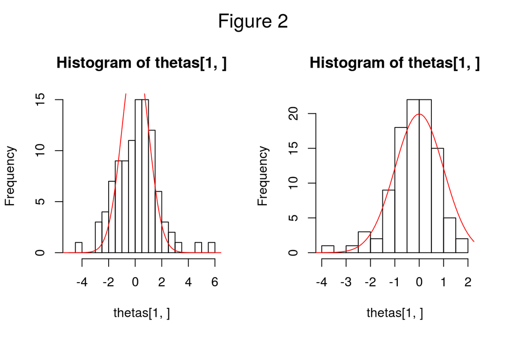

```r
mtext("Figure 2", outer = TRUE, cex = 1.5)
```

## Bootstrap distribution

In order to bootstrap the null, define

$C = \frac{VU^T \hat{A} + \hat{B}}{2}$

The null hypothesis is that

$H_0: E[X] = UV^T C,\ E[Y] = C.$

Therefore, compute residuals

$E^{(X, i)} = X^{(i)} - \hat{A}$

$E^{(Y, i)} = Y^{(i)} - \hat{B}$

and resample from

$X^* = UV^T C + E^{(X, i^*)}$ $Y^* = C + E^{(Y, i^*)}$

The bootstrap resampler is implemented in `boot_sampler`. The option `h0 = TRUE` resamples from the fitted null.

```r
boot_sampler <- function(res, h0 = FALSE) {
  p <- res$p; q <- res$q; dat <- res$dat; dat0 <- dat
  nX <- sum(dat[, 1] == 0); nY <- sum(dat[, 1] == 1);
  nX0 <- nX; nY0 <- nY
  rawX <- dat[dat[, 1]==0, -1]
  rawY <- dat[dat[, 1]==1, -1]
  residX <-t(t(rawX - colMeans(rawX)))
  residY <-t(t(rawY - colMeans(rawY)))
  mus <- sample_moments(res)
  ress <- svd(mus$Ahat %*% t(mus$Bhat))
  R <- ress$v %*% t(ress$u)
  C <- (R %*% mus$Ahat + mus$Bhat)/2
  AC <- t(R) %*% C
  vecC <- as.numeric(C)
  vecAC <- as.numeric(AC)
  if (h0) {
    sampler <- function(nX = nX0, nY = nY0) {
      if (nX == 0 & nY == 0) {
        return(list(p = p, q = q, dat = dat0))
      }
      newX <- residX[sample(nX, nX, TRUE), , drop = FALSE]
      newY <- residY[sample(nY, nY, TRUE), , drop = FALSE]
      newX <- t(t(newX) + vecAC)
      newY <- t(t(newY) + vecC)
      dat <- rbind(cbind(0, newX), cbind(1, newY))
      list(p = p, q = q, dat = dat)
    }
  } else {
    sampler <- function(nX = nX0, nY = nY0) {
      if (nX == 0 & nY == 0) {
        return(list(p = p, q = q, dat = dat0))
      }
      newX <- rawX[sample(nX, nX, TRUE), , drop = FALSE]
      newY <- rawY[sample(nY, nY, TRUE), , drop = FALSE]
      dat <- rbind(cbind(0, newX), cbind(1, newY))
      list(p = p, q = q, dat = dat)
    }
  }
  sampler
}
```

The sampling distribution of the bootstrap should resemble the original sampling distribution.

Figure 3: Example wth true null.

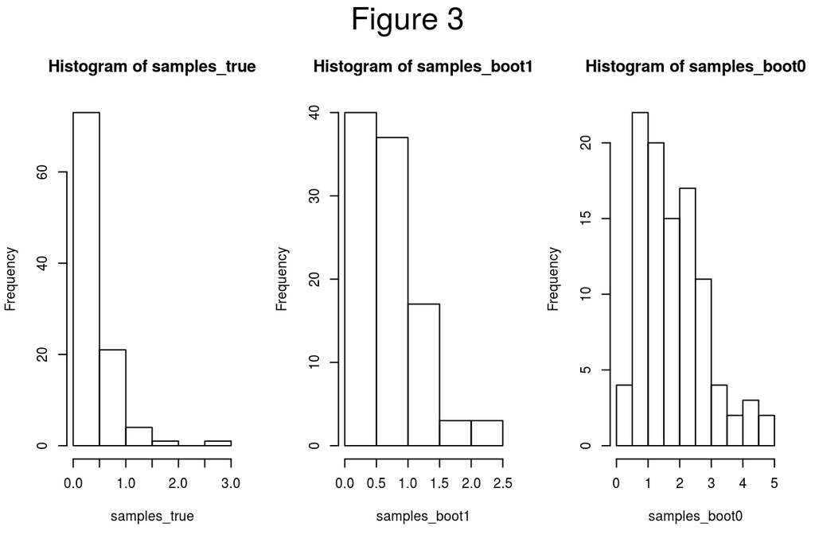

```r
par(mfrow=c(1, 3),oma = c(0, 0, 2, 0))
theta <- stat.T.nm
nX  <- 50; nY <- 50
mc.reps <- 100
samples_true <- sampling_dist(h0_small, theta, nX, nY, mc.reps, TRUE)
hist(samples_true)
res <- h0_small(nX, nY)
boot_s1 <- boot_sampler(res, h0 = FALSE)
samples_boot1 <- sampling_dist(boot_s1, theta, nX, nY, mc.reps, TRUE)
hist(samples_boot1)
boot_s0 <- boot_sampler(res, h0 = TRUE)
samples_boot0 <- sampling_dist(boot_s0, theta, nX, nY, mc.reps, TRUE)
hist(samples_boot0)
mtext("Figure 3", outer = TRUE, cex = 1.5)
```

Figure 4: Example wth true alernative.

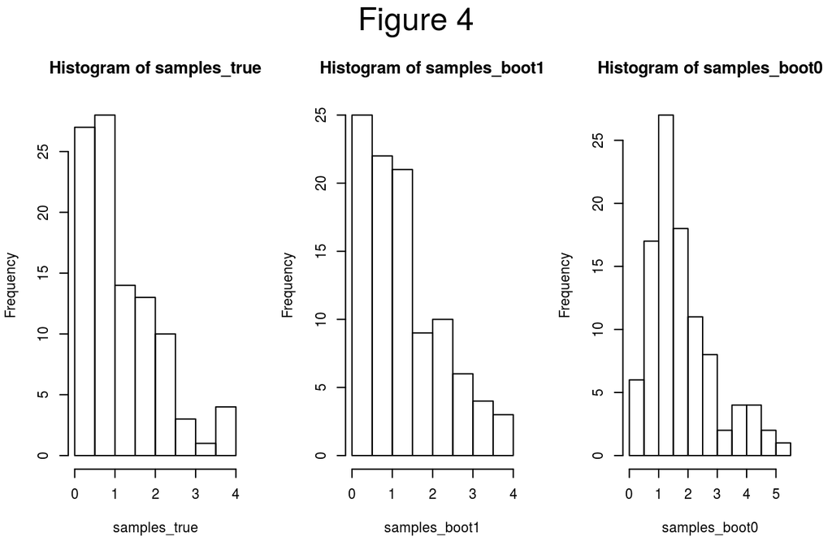

```r
par(mfrow=c(1, 3),oma = c(0, 0, 2, 0))
theta <- stat.T.nm
nX  <- 50; nY <- 50
mc.reps <- 100
samples_true <- sampling_dist(h1_small, theta, nX, nY, mc.reps, TRUE)
hist(samples_true)
res <- h1_small(nX, nY)
boot_s1 <- boot_sampler(res, h0 = FALSE)
samples_boot1 <- sampling_dist(boot_s1, theta, nX, nY, mc.reps, TRUE)
hist(samples_boot1)
boot_s0 <- boot_sampler(res, h0 = TRUE)
samples_boot0 <- sampling_dist(boot_s0, theta, nX, nY, mc.reps, TRUE)
hist(samples_boot0)
mtext("Figure 4", outer = TRUE, cex = 1.5)
```

# Bootstrap tests

For either the $T$ or $S$ statistic, we can test the global either by testing the norm, or doing multiple testing:

- A single hypothesis test, $||T||_F^2 = 0$.
- Multiple hypothesis tests, $T_{ij} = 0$.

To get p-values using bootstrap, one can either invert the confidence interval, or bootstrap the null.

```r
inverse_ci_test <- function(res, theta, mc.reps = 1000) {
  nX <- sum(res$dat[, 1] ==0); nY <- sum(res$dat[, 1]==1)
  boot_s1 <- boot_sampler(res, FALSE)
  thetas <- sampling_dist(boot_s1, theta, nX, nY, mc.reps, TRUE)
  pvs <- apply(thetas, 1, function(v) {
    p1 <- (sum(v > 0) + 1)/(mc.reps + 1)
    p2 <- (sum(v < 0) + 1)/(mc.reps + 1)
    2 * pmin(p1, p2)
  })
  min(pvs) * length(pvs)
}

boot_null_test <- function(res, theta, mc.reps = 1000) {
  nX <- sum(res$dat[, 1] ==0); nY <- sum(res$dat[, 1]==1)
  boot_s0 <- boot_sampler(res, TRUE)
  theta0 <- theta(res)
  thetas <- sampling_dist(boot_s0, theta, nX, nY, mc.reps, TRUE)
  pvs <- sapply(1:length(theta0), function(i) {
    v <- thetas[i, ]; v0 <- theta0[i]
    p1 <- (sum(v > v0) + 1)/(mc.reps + 1)
    p2 <- (sum(v < v0) + 1)/(mc.reps + 1)
    2 * pmin(p1, p2)
  })
  min(pvs) * length(pvs)
}
```

## Example

```r
nX <- 100; nY <- 100; mc.reps = 1000
res0 <- h0_small(nX, nY)
res1 <- h1_small(nX, nY)

## stat T
c(inverse_ci_test(res0, stat.T, mc.reps), inverse_ci_test(res1, stat.T, mc.reps))
```

```
## [1] 1.1588412 0.1398601
```

```r
c(inverse_ci_test(res0, stat.T.s, mc.reps), inverse_ci_test(res1, stat.T.s, mc.reps))
```

```
## [1] 1.0389610 0.1198801
```

```r
c(inverse_ci_test(res0, stat.T.bs, mc.reps), inverse_ci_test(res1, stat.T.bs, mc.reps))
```

```
## [1] 0.81918082 0.05994006
```

```r
c(boot_null_test(res0, stat.T, mc.reps), boot_null_test(res1, stat.T, mc.reps))
```

```
## [1] 0.05994006 1.49850150
```

```r
c(boot_null_test(res0, stat.T.s, mc.reps), boot_null_test(res1, stat.T.s, mc.reps))
```

```
## [1] 0.0999001 3.4565435
```

```r
c(boot_null_test(res0, stat.T.bs, mc.reps), boot_null_test(res1, stat.T.bs, mc.reps))
```

```
## [1] 0.01998002 3.37662338
```

```r
## stat T norm
c(inverse_ci_test(res0, stat.T.nm, mc.reps), inverse_ci_test(res1, stat.T.nm, mc.reps))
```

```
## [1] 0.001998002 0.001998002
```

```r
c(inverse_ci_test(res0, stat.T.ns, mc.reps), inverse_ci_test(res1, stat.T.ns, mc.reps))
```

```
## [1] 0.001998002 0.001998002
```

```r
c(inverse_ci_test(res0, stat.T.nbs, mc.reps), inverse_ci_test(res1, stat.T.nbs, mc.reps))
```

```
## [1] 0.5754246 0.1138861
```

```r
c(boot_null_test(res0, stat.T.nm, mc.reps), boot_null_test(res1, stat.T.nm, mc.reps))
```

```
## [1] 0.7052947 0.3836164
```

```r
c(boot_null_test(res0, stat.T.ns, mc.reps), boot_null_test(res1, stat.T.ns, mc.reps))
```

```
## [1] 0.8691309 0.2897103
```

```r
c(boot_null_test(res0, stat.T.nbs, mc.reps), boot_null_test(res1, stat.T.nbs, mc.reps))
```

```
## [1] 0.9450549 0.4015984
```

```r
## stat S
c(inverse_ci_test(res0, stat.S, mc.reps), inverse_ci_test(res1, stat.S, mc.reps))
```

```
## [1] 0.41558442 0.02397602
```

```r
c(inverse_ci_test(res0, stat.S.s, mc.reps), inverse_ci_test(res1, stat.S.s, mc.reps))
```

```
## [1] 0.29570430 0.02397602
```

```r
c(inverse_ci_test(res0, stat.S.bs, mc.reps), inverse_ci_test(res1, stat.S.bs, mc.reps))
```

```
## [1] 0.35964036 0.03996004
```

```r
c(boot_null_test(res0, stat.S, mc.reps), boot_null_test(res1, stat.S, mc.reps))
```

```
## [1] 0.1598402 0.3996004
```

```r
c(boot_null_test(res0, stat.S.s, mc.reps), boot_null_test(res1, stat.S.s, mc.reps))
```

```
## [1] 0.03196803 1.25474525
```

```r
c(boot_null_test(res0, stat.S.bs, mc.reps), boot_null_test(res1, stat.S.bs, mc.reps))
```

```
## [1] 0.007992008 0.991008991
```

```r
## stat S norm
c(inverse_ci_test(res0, stat.S.nm, mc.reps), inverse_ci_test(res1, stat.S.nm, mc.reps))
```

```
## [1] 0.001998002 0.001998002
```

```r
c(inverse_ci_test(res0, stat.S.ns, mc.reps), inverse_ci_test(res1, stat.S.ns, mc.reps))
```

```
## [1] 0.001998002 0.001998002
```

```r
c(inverse_ci_test(res0, stat.S.nbs, mc.reps), inverse_ci_test(res1, stat.S.nbs, mc.reps))
```

```
## [1] 0.6873127 0.1058941
```

```r
c(boot_null_test(res0, stat.S.nm, mc.reps), boot_null_test(res1, stat.S.nm, mc.reps))
```

```
## [1] 0.13786214 0.08591409
```

```r
c(boot_null_test(res0, stat.S.ns, mc.reps), boot_null_test(res1, stat.S.ns, mc.reps))
```

```
## [1] 0.8191808 0.6533467
```

```r
c(boot_null_test(res0, stat.S.nbs, mc.reps), boot_null_test(res1, stat.S.nbs, mc.reps))
```

```
## [1] 0.9930070 0.7052947
```

# Better bootstrap intervals

The BCA alpha is given by

$\alpha_{BCA} = \Phi\left(z_0 + \frac{z_0 + z^{(\alpha)}}{1 - a (z_0 + z^{(\alpha)})}\right)$

Hence, to invert the BCA interval, use

$\alpha = \Phi\left( \frac{(1-az_0)(z^{BCA} - z_0) - z_0}{1 + a (z^{BCA} - z_0)} \right)$

```r
alpha_bca <- function(alpha, z0, acc) {
  za <- qnorm(alpha)
  pnorm(
    z0 + (z0 + za)/(1 - acc * (z0 + za))
    )
}

inv_alpha_bca <- function(alpha_bca, z0, acc) {
  if (alpha_bca == 1) {
    return(1)
  }
  za <- qnorm(alpha_bca)
  pnorm(
    ((1 - acc * z0) * (za - z0) - z0)/
      (1 + acc * (za - z0))
    )
}

alpha_bca(0.1, 0.2, 0.01)
```

```
## [1] 0.1921559
```

```r
inv_alpha_bca(0.19251559, 0.2, 0.01)
```

```
## [1] 0.1002361
```

Code for BCA inverted p-values.

```r
theta <- stat.T

inverse_bca_test <- function(res, theta, mc.reps = 1000) {
  jj <- jackknife(res, theta)
  acc <- jj$skew/6
  boot_s1 <- boot_sampler(res, FALSE)
  thetas <- sampling_dist(boot_s1, theta, nX, nY, mc.reps, TRUE)
  theta0 <- theta(res)
  z0s <- sapply(1:length(theta0), function(i) {
    qnorm(sum(thetas[i, ] < theta0[i])/mc.reps)
  })
  pvs <- sapply(1:length(theta0), function(i) {
    v <- thetas[i, ]
    p1 <- (sum(v > 0) + 1)/(mc.reps + 1)
    p2 <- (sum(v < 0) + 1)/(mc.reps + 1)
    p1_mod <- inv_alpha_bca(p1, z0s[i], acc[i])
    p2_mod <- inv_alpha_bca(p2, -z0s[i], acc[i])
    2 * pmin(p1_mod, p2_mod)
  })
  min(pvs) * length(pvs)
}
```

## Example

```r
nX <- 100; nY <- 100; mc.reps = 1000
res0 <- h0_small(nX, nY)
res1 <- h1_small(nX, nY)

c(inverse_bca_test(res0, stat.T, mc.reps), inverse_bca_test(res1, stat.T, mc.reps))
```

```
## [1] 0.5976781 0.6300540
```

```r
c(inverse_bca_test(res0, stat.T.nm, mc.reps), inverse_bca_test(res1, stat.T.nm, mc.reps))
```

```
## [1] 0.0004419834 0.0002548869
```

```r
c(inverse_bca_test(res0, stat.S, mc.reps), inverse_bca_test(res1, stat.S, mc.reps))
```

```
## [1] 0.2212882 0.1629338
```

```r
c(inverse_bca_test(res0, stat.S.nm, mc.reps), inverse_bca_test(res1, stat.S.nm, mc.reps))
```

```
## [1] 0.0002585495 0.0005663543
```